# Posterior problem with Sigma mixture prior

Cory Lanker

4/23/2017

## A potential problem with the posterior under some Sigma prior conditions

When there is an overfit input Sigma including in the mixture, the likelihood and prior could have the same form for that collection of observations, and there won’t be a prior for smoothing the posterior. This potentially complicates

1. prediction of new points, since there may be overfit regions where we would like a smoothed regression function,
2. clustering data points in the training set, as points that should be in the same group are split due to the likelihood/prior fixation on the Sigma input prior that matches a subset of the points of that presumed single cluster.

I’ll only consider the impact of duplicate mixture covariance/sample covariance on prediction (#1 above)

### Files used in these simulation study

Files are found in ~/Dropbox/final/testing kmixfun_v36.R has the R functions (copied from/based on v35) Directory ‘code’ has the C functions These simulations evolved in files testrun170404.R and testrun170416.R

## Problem Summary

An instability exists in the program when there is an isolated grouping of observations that has its own input covariance matrix. The problem occurs when there is a cluster of those points in the Gibbs sampler with no other points. When this occurs:

1. it is unlikely that other points will join the cluster,
2. it is unlikely that the cluster points leave the cluster,
3. the cluster mean will not change much
4. the cluster covariance will not change at all
5. the cluster proportion is unlikely to become small enough to affect any of the above

### Other points stay out of cluster

### Group points stay in cluster

### Cluster mean does not change

### Cluster covariance does not change

```r
X1 = mvrnorm(n=10, c(0,0,0), diag(3)*2)
X2 = mvrnorm(n=10, c(0,0,0), diag(3) + .5)
V1 = cov(X1); V2 = cov(X2)
det(V1)
```

```
## [1] 1.237931
```

```r
det(V2)
```

```
## [1] 1.201671
```

```r
det(V1+V2)
```

```
## [1] 22.5819
```

```r
det(V1+V1)
```

```
## [1] 9.903446
```

```r
det(V2+V2)
```

```
## [1] 9.613365
```

```r
# Difference from Wishart draws
I2 = solve(V2)/7
solve(rWishart(1, 7, I2)[,,1])
```

```
##            [,1]       [,2]      [,3]
## [1,] 0.84771443 0.09158036 0.6103570
## [2,] 0.09158036 1.20690451 0.1693834
## [3,] 0.61035698 0.16938336 1.2282753
```

```r
S2 = diag(3)
S2[1,3]=S2[3,1]=10; S2[3,3]=150
X2 = mvrnorm(n=10, c(0,0,0), S2)
V2 = cov(X2)
I2 = solve(V2)/7
solve(rWishart(1, 7, I2)[,,1])
```

```
##            [,1]      [,2]       [,3]
## [1,]  3.7050064 0.9457945  28.020109
## [2,]  0.9457945 0.5971781   7.615266
## [3,] 28.0201089 7.6152661 235.773803
```

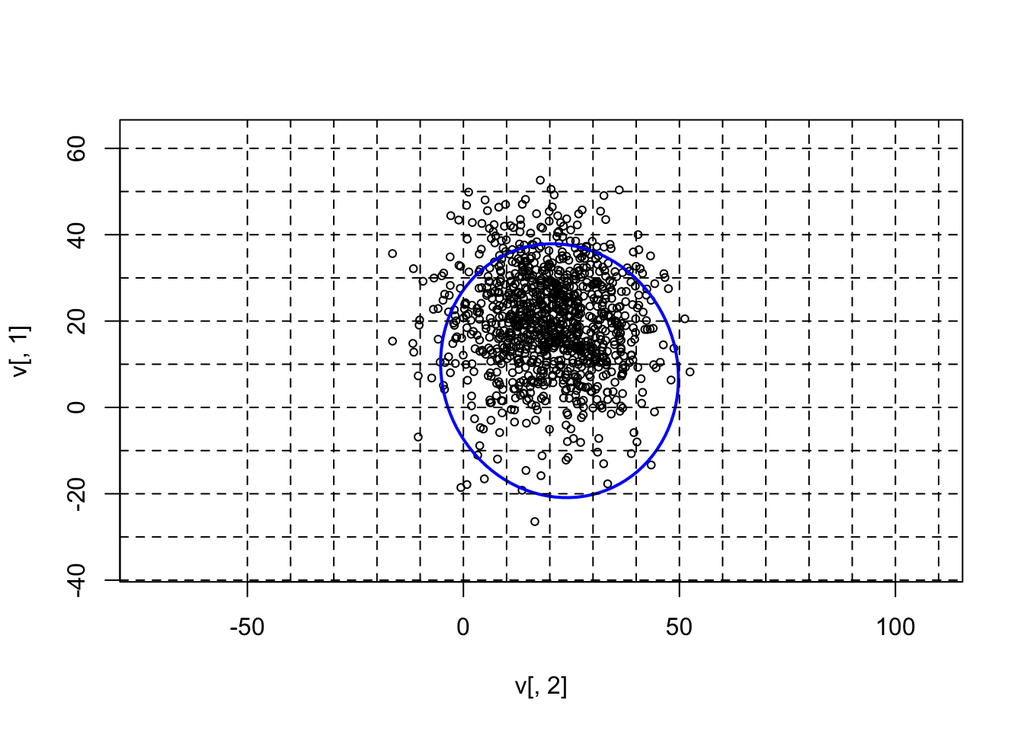

```r
f = rWishart(1,10,diag(2)*9)[,,1]
center=c(20,20)
v = mvrnorm(n=1000, mu=center, Sigma=f)
plot.new()
plot(v[,2], v[,1],pch=1,cex=.67,asp=1,
    xlim=range(v[,2])+c(-10,10),ylim=range(v[,1])+c(-10,10))
ellipse.ci(v, f, .95, 'blue', 2)
abline(h=-5:11*10,v=-5:11*10,lty=2)
```